# numerical integration & validation

Linked [*here*](https://github.com/vaabe/nbody/verlet) are a few integrators written in C++.

## setup

In Cartesian coordinates, ${{\boldsymbol r}} = {{\boldsymbol r}}(x,y,z)$, and there are three second order ODEs that must be integrated for each body:

$${\ddot{\boldsymbol{r}}} = \sum_{i, i \neq j}^n \frac{G m_j}{r_{ij}^3} ({{\boldsymbol r}}_j - {{\boldsymbol r}}_i) =
\begin{cases}
\ddot x = \sum_{i, i \neq j}^n \frac{G m_j}{r_{ij}^3} (x_j - x_i) \\
\ddot y = \sum_{i, i \neq j}^n \frac{G m_j}{r_{ij}^3} (y_j - y_i) \tag{1} \\
\ddot z = \sum_{i, i \neq j}^n \frac{G m_j}{r_{ij}^3} (z_j - z_i) \\
\end{cases}$$

For n bodies there are a total of 3n second order ODEs for the whole problem. Most integrators involve transforming these equations into 6n first order equations, by defining a velocity variable ${{\boldsymbol v}}$:

$${\dot{\boldsymbol{r}}} = {{\boldsymbol v}} \tag{2}$$

where ${{\boldsymbol v}} = {{\boldsymbol v}}(v_x, v_y, v_z)$. Equation (1) can then be written as a first order equation in the form ${\dot{\boldsymbol{v}}} = f({{\boldsymbol r}}, t)$ and the solution for ${{\boldsymbol v}}(t)$ can be recombined to get ${{\boldsymbol r}}(t)$.

In the sections below, various integrators are validated by testing them on the two-body problem and comparing the numerical solutions to the known analytic solution.

## verlet integration

Verlet integration involves computing the positions at each time step by extrapolating from the velocity at the previous half time step. The following equations are repeatedly applied to obtain the positions at subsequent time steps:

$${{\boldsymbol v}}(t + \tfrac 12 {\text{d}}t) = {{\boldsymbol v}}(t) + \tfrac 12 {{\boldsymbol a}}(t) {\text{d}}t$$

$${{\boldsymbol r}}(t + {\text{d}}t) = {{\boldsymbol r}}(t) + {{\boldsymbol v}}(t + \tfrac 12 {\text{d}}t) {\text{d}}t$$

Verlet integration is time-reversal symmetric and provides numeric solutions that are stable in the long run. For this reason the Verlet method is often favourable compared to more precise methods such as Runge-Kutta and Hermite integration, as the latter do not guarantee long-run stability as consistently.

## testing the orbital period

Using rescaled variables with $G=1$, $m_1 = 0.999$, $m_2 = 0.001$, and the following initial positions and velocities:

$$m_1 =
\begin{cases}
{x_0 = 0, y_0 = 0} \\
{vx_0 = 0, vy_0 = 0}
\end{cases}$$

$$m_2 =
\begin{cases}
{x_0 = 1, y_0 = 0} \\
{vx_0 = 0, vy_0 = 0.7}
\end{cases}$$

Below is a plot of $r$ on $t$:

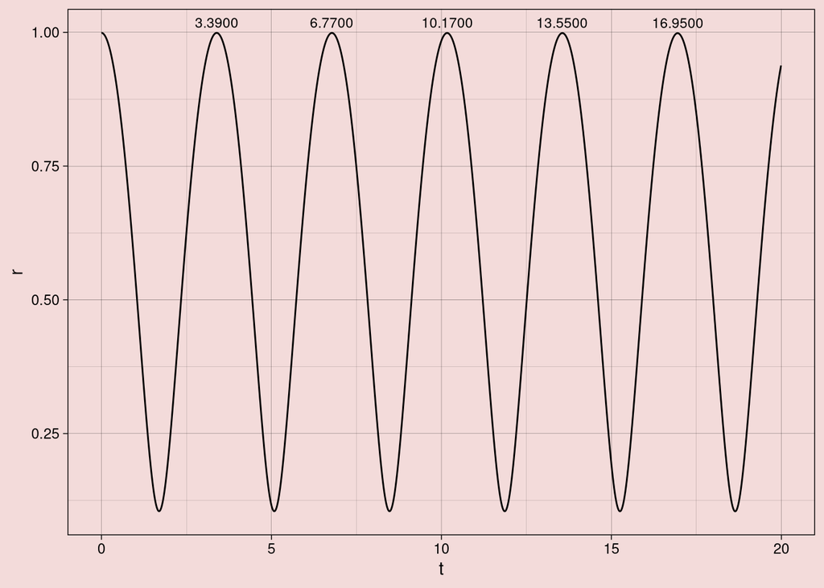

The numerical period is:

```r
tau = 6.77-3.39
tau
```

```
## [1] 3.38
```

where $a$ is the semimajor (the distance from the aphelion/perihelion to the origin).

```r
a = abs((df$x2[aph_index] - df$x2[peri_index])/2)
period = sqrt((4 * pi**2 * a**3)/(G*(m1+m2)))
period
```

```
## [1] 3.382034
```

Consistent.